# Risk Factor Analysis

## Outcome Variable

**Outcome Variable:** pers_wast

## Predictor Variables

**Intervention Variable:** gagebrth

**Adjustment Set:**

- arm
- sex
- W_mage
- meducyrs
- feducyrs
- hhwealth_quart
- single
- brthmon
- W_parity
- delta_W_mage
- delta_meducyrs
- delta_feducyrs
- delta_hhwealth_quart
- delta_single
- delta_brthmon
- delta_W_parity

## Stratifying Variables

The analysis was stratified on these variable(s):

- agecat
- studyid
- country

## Data Summary

| agecat | studyid | country | gagebrth | pers_wast | n_cell | n |
| --- | --- | --- | --- | --- | --- | --- |
| 0-24 months | CMC-V-BCS-2002 | INDIA | Full or late term | 0 | 201 | 351 |
| 0-24 months | CMC-V-BCS-2002 | INDIA | Full or late term | 1 | 14 | 351 |
| 0-24 months | CMC-V-BCS-2002 | INDIA | Preterm | 0 | 49 | 351 |
| 0-24 months | CMC-V-BCS-2002 | INDIA | Preterm | 1 | 3 | 351 |
| 0-24 months | CMC-V-BCS-2002 | INDIA | Early term | 0 | 81 | 351 |
| 0-24 months | CMC-V-BCS-2002 | INDIA | Early term | 1 | 3 | 351 |
| 0-24 months | COHORTS | GUATEMALA | Full or late term | 0 | 401 | 732 |
| 0-24 months | COHORTS | GUATEMALA | Full or late term | 1 | 8 | 732 |
| 0-24 months | COHORTS | GUATEMALA | Preterm | 0 | 113 | 732 |
| 0-24 months | COHORTS | GUATEMALA | Preterm | 1 | 6 | 732 |
| 0-24 months | COHORTS | GUATEMALA | Early term | 0 | 198 | 732 |
| 0-24 months | COHORTS | GUATEMALA | Early term | 1 | 6 | 732 |
| 0-24 months | COHORTS | INDIA | Full or late term | 0 | 470 | 1186 |
| 0-24 months | COHORTS | INDIA | Full or late term | 1 | 42 | 1186 |
| 0-24 months | COHORTS | INDIA | Preterm | 0 | 248 | 1186 |
| 0-24 months | COHORTS | INDIA | Preterm | 1 | 18 | 1186 |
| 0-24 months | COHORTS | INDIA | Early term | 0 | 367 | 1186 |
| 0-24 months | COHORTS | INDIA | Early term | 1 | 41 | 1186 |
| 0-24 months | COHORTS | PHILIPPINES | Full or late term | 0 | 1034 | 2789 |
| 0-24 months | COHORTS | PHILIPPINES | Full or late term | 1 | 47 | 2789 |
| 0-24 months | COHORTS | PHILIPPINES | Preterm | 0 | 550 | 2789 |
| 0-24 months | COHORTS | PHILIPPINES | Preterm | 1 | 34 | 2789 |
| 0-24 months | COHORTS | PHILIPPINES | Early term | 0 | 1062 | 2789 |
| 0-24 months | COHORTS | PHILIPPINES | Early term | 1 | 62 | 2789 |
| 0-24 months | IRC | INDIA | Full or late term | 0 | 225 | 390 |
| 0-24 months | IRC | INDIA | Full or late term | 1 | 25 | 390 |
| 0-24 months | IRC | INDIA | Preterm | 0 | 34 | 390 |
| 0-24 months | IRC | INDIA | Preterm | 1 | 8 | 390 |
| 0-24 months | IRC | INDIA | Early term | 0 | 85 | 390 |
| 0-24 months | IRC | INDIA | Early term | 1 | 13 | 390 |
| 0-24 months | JiVitA-3 | BANGLADESH | Full or late term | 0 | 7749 | 15049 |
| 0-24 months | JiVitA-3 | BANGLADESH | Full or late term | 1 | 434 | 15049 |
| 0-24 months | JiVitA-3 | BANGLADESH | Preterm | 0 | 2534 | 15049 |
| 0-24 months | JiVitA-3 | BANGLADESH | Preterm | 1 | 172 | 15049 |
| 0-24 months | JiVitA-3 | BANGLADESH | Early term | 0 | 3908 | 15049 |
| 0-24 months | JiVitA-3 | BANGLADESH | Early term | 1 | 252 | 15049 |
| 0-24 months | Keneba | GAMBIA | Full or late term | 0 | 733 | 1579 |
| 0-24 months | Keneba | GAMBIA | Full or late term | 1 | 45 | 1579 |
| 0-24 months | Keneba | GAMBIA | Preterm | 0 | 226 | 1579 |
| 0-24 months | Keneba | GAMBIA | Preterm | 1 | 13 | 1579 |
| 0-24 months | Keneba | GAMBIA | Early term | 0 | 533 | 1579 |
| 0-24 months | Keneba | GAMBIA | Early term | 1 | 29 | 1579 |
| 0-24 months | NIH-Crypto | BANGLADESH | Full or late term | 0 | 156 | 730 |
| 0-24 months | NIH-Crypto | BANGLADESH | Full or late term | 1 | 2 | 730 |
| 0-24 months | NIH-Crypto | BANGLADESH | Preterm | 0 | 241 | 730 |
| 0-24 months | NIH-Crypto | BANGLADESH | Preterm | 1 | 14 | 730 |
| 0-24 months | NIH-Crypto | BANGLADESH | Early term | 0 | 307 | 730 |
| 0-24 months | NIH-Crypto | BANGLADESH | Early term | 1 | 10 | 730 |
| 0-24 months | PROBIT | BELARUS | Full or late term | 0 | 8401 | 16583 |
| 0-24 months | PROBIT | BELARUS | Full or late term | 1 | 72 | 16583 |
| 0-24 months | PROBIT | BELARUS | Preterm | 0 | 574 | 16583 |
| 0-24 months | PROBIT | BELARUS | Preterm | 1 | 6 | 16583 |
| 0-24 months | PROBIT | BELARUS | Early term | 0 | 7474 | 16583 |
| 0-24 months | PROBIT | BELARUS | Early term | 1 | 56 | 16583 |
| 0-24 months | TanzaniaChild2 | TANZANIA, UNITED REPUBLIC OF | Full or late term | 0 | 1212 | 2035 |
| 0-24 months | TanzaniaChild2 | TANZANIA, UNITED REPUBLIC OF | Full or late term | 1 | 33 | 2035 |
| 0-24 months | TanzaniaChild2 | TANZANIA, UNITED REPUBLIC OF | Preterm | 0 | 306 | 2035 |
| 0-24 months | TanzaniaChild2 | TANZANIA, UNITED REPUBLIC OF | Preterm | 1 | 11 | 2035 |
| 0-24 months | TanzaniaChild2 | TANZANIA, UNITED REPUBLIC OF | Early term | 0 | 462 | 2035 |
| 0-24 months | TanzaniaChild2 | TANZANIA, UNITED REPUBLIC OF | Early term | 1 | 11 | 2035 |

The following strata were considered:

- agecat: 0-24 months, studyid: CMC-V-BCS-2002, country: INDIA
- agecat: 0-24 months, studyid: COHORTS, country: GUATEMALA
- agecat: 0-24 months, studyid: COHORTS, country: INDIA
- agecat: 0-24 months, studyid: COHORTS, country: PHILIPPINES
- agecat: 0-24 months, studyid: IRC, country: INDIA
- agecat: 0-24 months, studyid: JiVitA-3, country: BANGLADESH
- agecat: 0-24 months, studyid: Keneba, country: GAMBIA
- agecat: 0-24 months, studyid: NIH-Crypto, country: BANGLADESH
- agecat: 0-24 months, studyid: PROBIT, country: BELARUS
- agecat: 0-24 months, studyid: TanzaniaChild2, country: TANZANIA, UNITED REPUBLIC OF

### Dropped Strata

Some strata were dropped due to rare outcomes:

- agecat: 0-24 months, studyid: CMC-V-BCS-2002, country: INDIA
- agecat: 0-24 months, studyid: NIH-Crypto, country: BANGLADESH

## Methods Detail

We're interested in the causal parameters $E[Y_a]$ for all values of $a \in \mathcal{A}$. These parameters represent the mean outcome if, possibly contrary to fact, we intervened to set all units to have $A=a$. Under the randomization and positivity assumptions, these are identified by the statistical parameters $\psi_a=E_W[E_{Y|A,W}(Y|A=a,W)]$. In addition, we're interested in the mean of $Y$, $E[Y]$ under no intervention (the observed mean). We will estimate these parameters by using SuperLearner to fit the relevant likelihood factors -- $E_{Y|A,W}(Y|A=a,W)$ and $p(A=a|W)$, and then updating our likelihood fit using a joint TMLE.

For unadjusted analyses ($W=\{\}$), initial likelihoods were estimated using Lrnr_glm to estimate the simple $E(Y|A)$ and Lrnr_mean to estimate $p(A)$. For adjusted analyses, a small library containing Lrnr_glmnet, Lrnr_xgboost, and Lrnr_mean was used.

Having estimated these parameters, we will then use the delta method to estimate relative risks and attributable risks relative to a prespecified baseline level of $A$.

# Results Detail

## Results Plots

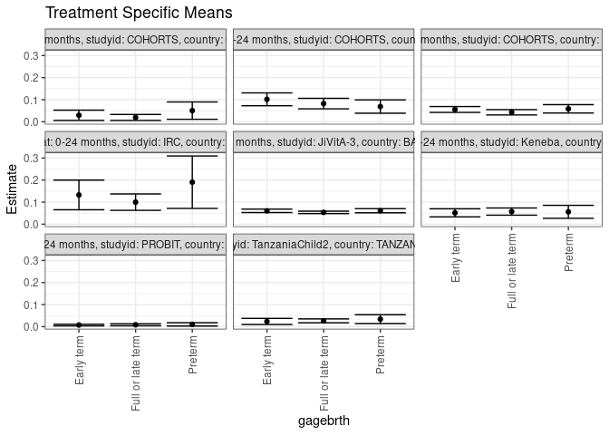

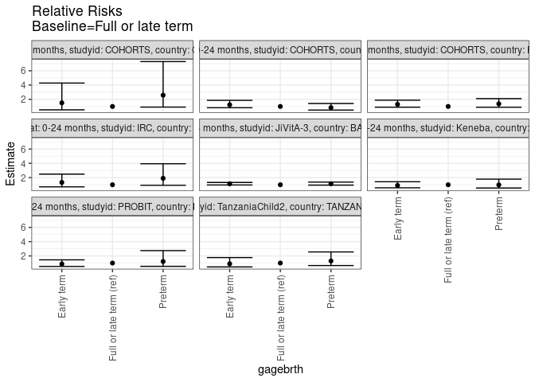

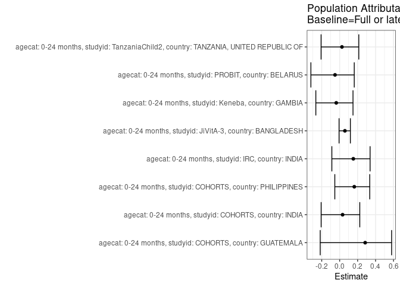

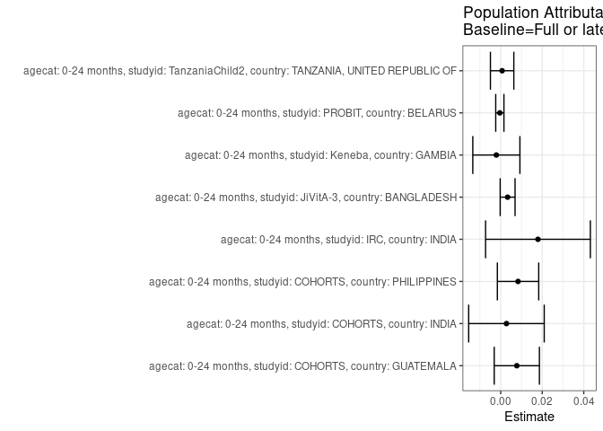

## Results Table

### Parameter: TSM

| agecat | studyid | country | intervention_level | baseline_level | estimate | ci_lower | ci_upper |
| --- | --- | --- | --- | --- | --- | --- | --- |
| 0-24 months | COHORTS | GUATEMALA | Full or late term | NA | 0.0195599 | 0.0061299 | 0.0329899 |
| 0-24 months | COHORTS | GUATEMALA | Preterm | NA | 0.0504202 | 0.0110797 | 0.0897606 |
| 0-24 months | COHORTS | GUATEMALA | Early term | NA | 0.0294118 | 0.0062107 | 0.0526128 |
| 0-24 months | COHORTS | INDIA | Full or late term | NA | 0.0823895 | 0.0585420 | 0.1062369 |
| 0-24 months | COHORTS | INDIA | Preterm | NA | 0.0688340 | 0.0386828 | 0.0989852 |
| 0-24 months | COHORTS | INDIA | Early term | NA | 0.1016804 | 0.0725235 | 0.1308374 |
| 0-24 months | COHORTS | PHILIPPINES | Full or late term | NA | 0.0429229 | 0.0308063 | 0.0550396 |
| 0-24 months | COHORTS | PHILIPPINES | Preterm | NA | 0.0586401 | 0.0396818 | 0.0775983 |
| 0-24 months | COHORTS | PHILIPPINES | Early term | NA | 0.0556643 | 0.0423249 | 0.0690037 |
| 0-24 months | IRC | INDIA | Full or late term | NA | 0.1000000 | 0.0627645 | 0.1372355 |
| 0-24 months | IRC | INDIA | Preterm | NA | 0.1904762 | 0.0715668 | 0.3093856 |
| 0-24 months | IRC | INDIA | Early term | NA | 0.1326531 | 0.0654100 | 0.1998961 |
| 0-24 months | JiVitA-3 | BANGLADESH | Full or late term | NA | 0.0536817 | 0.0481834 | 0.0591800 |
| 0-24 months | JiVitA-3 | BANGLADESH | Preterm | NA | 0.0611685 | 0.0517558 | 0.0705813 |
| 0-24 months | JiVitA-3 | BANGLADESH | Early term | NA | 0.0606086 | 0.0528590 | 0.0683583 |
| 0-24 months | Keneba | GAMBIA | Full or late term | NA | 0.0571938 | 0.0409202 | 0.0734674 |
| 0-24 months | Keneba | GAMBIA | Preterm | NA | 0.0561472 | 0.0266725 | 0.0856219 |
| 0-24 months | Keneba | GAMBIA | Early term | NA | 0.0515458 | 0.0333044 | 0.0697872 |
| 0-24 months | PROBIT | BELARUS | Full or late term | NA | 0.0084976 | 0.0040221 | 0.0129731 |
| 0-24 months | PROBIT | BELARUS | Preterm | NA | 0.0103448 | 0.0029413 | 0.0177483 |
| 0-24 months | PROBIT | BELARUS | Early term | NA | 0.0074369 | 0.0037707 | 0.0111031 |
| 0-24 months | TanzaniaChild2 | TANZANIA, UNITED REPUBLIC OF | Full or late term | NA | 0.0263407 | 0.0174320 | 0.0352494 |
| 0-24 months | TanzaniaChild2 | TANZANIA, UNITED REPUBLIC OF | Preterm | NA | 0.0340482 | 0.0138947 | 0.0542016 |
| 0-24 months | TanzaniaChild2 | TANZANIA, UNITED REPUBLIC OF | Early term | NA | 0.0236723 | 0.0097769 | 0.0375676 |

### Parameter: E(Y)

| agecat | studyid | country | intervention_level | baseline_level | estimate | ci_lower | ci_upper |
| --- | --- | --- | --- | --- | --- | --- | --- |
| 0-24 months | COHORTS | GUATEMALA | NA | NA | 0.0273224 | 0.0155047 | 0.0391401 |
| 0-24 months | COHORTS | INDIA | NA | NA | 0.0851602 | 0.0692682 | 0.1010522 |
| 0-24 months | COHORTS | PHILIPPINES | NA | NA | 0.0512729 | 0.0430860 | 0.0594597 |
| 0-24 months | IRC | INDIA | NA | NA | 0.1179487 | 0.0858959 | 0.1500016 |
| 0-24 months | JiVitA-3 | BANGLADESH | NA | NA | 0.0570138 | 0.0528460 | 0.0611815 |
| 0-24 months | Keneba | GAMBIA | NA | NA | 0.0550982 | 0.0438403 | 0.0663560 |
| 0-24 months | PROBIT | BELARUS | NA | NA | 0.0080806 | 0.0045539 | 0.0116073 |
| 0-24 months | TanzaniaChild2 | TANZANIA, UNITED REPUBLIC OF | NA | NA | 0.0270270 | 0.0199797 | 0.0340743 |

### Parameter: RR

| agecat | studyid | country | intervention_level | baseline_level | estimate | ci_lower | ci_upper |
| --- | --- | --- | --- | --- | --- | --- | --- |
| 0-24 months | COHORTS | GUATEMALA | Full or late term | Full or late term | 1.0000000 | 1.0000000 | 1.000000 |
| 0-24 months | COHORTS | GUATEMALA | Preterm | Full or late term | 2.5777311 | 0.9117126 | 7.288149 |
| 0-24 months | COHORTS | GUATEMALA | Early term | Full or late term | 1.5036765 | 0.5284081 | 4.278971 |
| 0-24 months | COHORTS | INDIA | Full or late term | Full or late term | 1.0000000 | 1.0000000 | 1.000000 |
| 0-24 months | COHORTS | INDIA | Preterm | Full or late term | 0.8354707 | 0.4941776 | 1.412470 |
| 0-24 months | COHORTS | INDIA | Early term | Full or late term | 1.2341434 | 0.8213223 | 1.854461 |
| 0-24 months | COHORTS | PHILIPPINES | Full or late term | Full or late term | 1.0000000 | 1.0000000 | 1.000000 |
| 0-24 months | COHORTS | PHILIPPINES | Preterm | Full or late term | 1.3661704 | 0.8900877 | 2.096896 |
| 0-24 months | COHORTS | PHILIPPINES | Early term | Full or late term | 1.2968426 | 0.8962744 | 1.876435 |
| 0-24 months | IRC | INDIA | Full or late term | Full or late term | 1.0000000 | 1.0000000 | 1.000000 |
| 0-24 months | IRC | INDIA | Preterm | Full or late term | 1.9047619 | 0.9207828 | 3.940254 |
| 0-24 months | IRC | INDIA | Early term | Full or late term | 1.3265306 | 0.7072263 | 2.488148 |
| 0-24 months | JiVitA-3 | BANGLADESH | Full or late term | Full or late term | 1.0000000 | 1.0000000 | 1.000000 |
| 0-24 months | JiVitA-3 | BANGLADESH | Preterm | Full or late term | 1.1394667 | 0.9481293 | 1.369417 |
| 0-24 months | JiVitA-3 | BANGLADESH | Early term | Full or late term | 1.1290369 | 0.9656256 | 1.320102 |
| 0-24 months | Keneba | GAMBIA | Full or late term | Full or late term | 1.0000000 | 1.0000000 | 1.000000 |
| 0-24 months | Keneba | GAMBIA | Preterm | Full or late term | 0.9817015 | 0.5402973 | 1.783717 |
| 0-24 months | Keneba | GAMBIA | Early term | Full or late term | 0.9012486 | 0.5722386 | 1.419424 |
| 0-24 months | PROBIT | BELARUS | Full or late term | Full or late term | 1.0000000 | 1.0000000 | 1.000000 |
| 0-24 months | PROBIT | BELARUS | Preterm | Full or late term | 1.2173851 | 0.5398571 | 2.745220 |
| 0-24 months | PROBIT | BELARUS | Early term | Full or late term | 0.8751808 | 0.5286513 | 1.448859 |
| 0-24 months | TanzaniaChild2 | TANZANIA, UNITED REPUBLIC OF | Full or late term | Full or late term | 1.0000000 | 1.0000000 | 1.000000 |
| 0-24 months | TanzaniaChild2 | TANZANIA, UNITED REPUBLIC OF | Preterm | Full or late term | 1.2926068 | 0.6537326 | 2.555835 |
| 0-24 months | TanzaniaChild2 | TANZANIA, UNITED REPUBLIC OF | Early term | Full or late term | 0.8986953 | 0.4565512 | 1.769031 |

### Parameter: PAR

| agecat | studyid | country | intervention_level | baseline_level | estimate | ci_lower | ci_upper |
| --- | --- | --- | --- | --- | --- | --- | --- |
| 0-24 months | COHORTS | GUATEMALA | Full or late term | NA | 0.0077625 | -0.0031218 | 0.0186468 |
| 0-24 months | COHORTS | INDIA | Full or late term | NA | 0.0027707 | -0.0154167 | 0.0209581 |
| 0-24 months | COHORTS | PHILIPPINES | Full or late term | NA | 0.0083499 | -0.0016092 | 0.0183090 |
| 0-24 months | IRC | INDIA | Full or late term | NA | 0.0179487 | -0.0072768 | 0.0431742 |
| 0-24 months | JiVitA-3 | BANGLADESH | Full or late term | NA | 0.0033320 | -0.0002508 | 0.0069149 |
| 0-24 months | Keneba | GAMBIA | Full or late term | NA | -0.0020956 | -0.0134374 | 0.0092461 |
| 0-24 months | PROBIT | BELARUS | Full or late term | NA | -0.0004170 | -0.0023921 | 0.0015581 |
| 0-24 months | TanzaniaChild2 | TANZANIA, UNITED REPUBLIC OF | Full or late term | NA | 0.0006863 | -0.0049481 | 0.0063208 |

### Parameter: PAF

| agecat | studyid | country | intervention_level | baseline_level | estimate | ci_lower | ci_upper |
| --- | --- | --- | --- | --- | --- | --- | --- |
| 0-24 months | COHORTS | GUATEMALA | Full or late term | NA | 0.2841076 | -0.2167890 | 0.5788079 |
| 0-24 months | COHORTS | INDIA | Full or late term | NA | 0.0325353 | -0.2063548 | 0.2241189 |
| 0-24 months | COHORTS | PHILIPPINES | Full or late term | NA | 0.1628525 | -0.0540576 | 0.3351256 |
| 0-24 months | IRC | INDIA | Full or late term | NA | 0.1521739 | -0.0870878 | 0.3387755 |
| 0-24 months | JiVitA-3 | BANGLADESH | Full or late term | NA | 0.0584429 | -0.0067027 | 0.1193728 |
| 0-24 months | Keneba | GAMBIA | Full or late term | NA | -0.0380345 | -0.2655382 | 0.1485712 |
| 0-24 months | PROBIT | BELARUS | Full or late term | NA | -0.0516073 | -0.3205094 | 0.1625369 |
| 0-24 months | TanzaniaChild2 | TANZANIA, UNITED REPUBLIC OF | Full or late term | NA | 0.0253946 | -0.2069749 | 0.2130278 |